# Bacterioplankton vs microbiome plot for field’s samples

Stepwise db-RDA for Bacterioplankton:

```r
#Load a full metadata for bacteria:
env_meta <- read.csv("/Users/u0145079/Library/CloudStorage/OneDrive-KULeuven/Desktop/PlasticDaphnia/Publication/Field_data/tables/Env_parameters+MPs.csv", row.names = 1)
bac_env_data = subset(env_meta,rownames(env_meta) %in% sample_names(ps_filtered_bac))
scaled_bac_env_data <- as.data.frame(scale(bac_env_data)) #scale metavariables due to different scales

sample_data(ps_filtered_bac) = scaled_bac_env_data
bray = vegdist(data.frame(otu_table(ps_filtered_bac)), method="bray")

dbrda = dbrda(bray ~ ., bac_env_data, dist="bray",na.action = na.exclude)
plot(dbrda)
anova(dbrda, by="terms", permu=200)
```

““” DAPHNIA MICROBIOME ““”

3. Is there statistical difference between AP and NP in Microbiome communities?

```r
# test homogeneity of variance
homog_test_cat <- betadisper(bray, data.frame(sample_data(ps_rarified_dap))$Category,bias.adjust=TRUE) #Calculate multivariate dispersions
disp_category=anova(homog_test_cat) #Perform test
print(disp_category)
```

```r
#Pielou
print(t.test(evenness_pielou~Category, data=tab)) # p-value = 0.282
```

[output not shown]

Conclusion: No sinigifcant difference in richness between MPs exposed and non-exposed

[figure not shown]

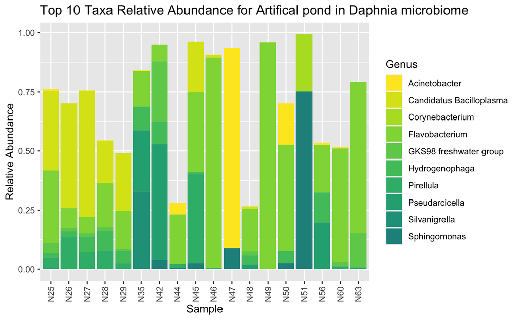

```r
dp_AP <- subset_samples(ps_filtered_dap.genus, Category=="Artifical pond")
# Top N taxa
N <- 10
top <- names(sort(taxa_sums(dp_AP), decreasing = TRUE))[1:N]

# Calculate relative abundance
ps_filtered_dap.genus.prop <- transform_sample_counts(dp_AP, function(x) x / sum(x) )

# Subset object to top N taxa
ps_filtered_dap.genus.prop.top <- prune_taxa(top, ps_filtered_dap.genus.prop)

ps_filtered_dap.genus.prop.top_df = psmelt(ps_filtered_dap.genus.prop.top)

ggplot(ps_filtered_dap.genus.prop.top_df, aes(x = Sample, y = Abundance, fill = Genus)) +
  geom_bar(stat = "identity") +
  theme(axis.text.x = element_text(angle = 90, hjust = 1, vjust = 0.5)) +
  labs(x = "Sample", y = "Relative Abundance", title = "Top 10 Taxa Relative Abundance for Artifical pond in Daphnia microbiome") +
  scale_fill_viridis_d(begin = 0.5, direction = -1)
```

These are the most abundant bacteria in AP that are not in NP: Corynebacterium GKS98 freshwater group (Burkholderiales Alcaligenaceae) Hydrogenophaga Pirellula Silvanigrella

PCoAs for Microbiome:

```r
ps_rarified_dap = readRDS("/Users/u0145079/Library/CloudStorage/OneDrive-KULeuven/Desktop/PlasticDaphnia/Field/Miseq/output/dada2/new/dap_rarified")
bray <- vegdist(data.frame(otu_table(ps_rarified_dap)), method="bray")
nMDS <- metaMDS(bray,k=2,distance = 'bray') #0.1776099
colors <- c("Natural pond" = "#6885d0", "Artifical pond" = "#cb5658")

# Update your plot code
p <- plot_ordination(ps_rarified_dap, nMDS, color = "Category") +
  geom_point(aes(color = Category), size = 3) +  # Ensure points are colored by Category
  scale_color_manual(values = colors) +  # Apply custom color scheme
  labs(title = "",
       x = "NMDS1",
       y = "NMDS2",
       color = "Sample Type",
       shape = "Location") +  # Updated labels with explained variance
  theme_pubr() +  # Minimal theme
  geom_point(size = 3) +  # Increase point size
  theme(legend.text = element_text(size = 6),  # Smaller legend text
        legend.title = element_text(size = 5),  # Smaller legend title
        legend.key.size = unit(0.5, "cm"))  # Smaller legend keys

p
```

Load envirionmental information:

```r
env_meta <- read.csv("/Users/u0145079/Library/CloudStorage/OneDrive-KULeuven/Desktop/PlasticDaphnia/Publication/Field_data/tables/Env_parameters+MPs.csv", row.names = 1)
dap_env_data = subset(env_meta,rownames(env_meta) %in% sample_names(ps_rarified_dap))
sam_data_dap = subset(sam_data,rownames(sam_data) %in% sample_names(ps_rarified_dap))
```

Running envfit:

```r
envfit_result <- envfit(nMDS, dap_env_data, permutations = 999, na.rm = TRUE) #Remove rows with missing samples
envfit_result
p = p.adjust.envfit(envfit_result)
p
```

Plot the NMDS ordination

```r
sam_data_dap$Category[sam_data_dap$Category == "Natural pond"] <- "Low MPs"
sam_data_dap$Category[sam_data_dap$Category == "Artifical pond"] <- "High MPs"
ordiplot(nMDS, display = "sites", type = "n")  #
colors <- c("High MPs" = "red", "Low MPs" = "blue")
# Add colored points based on 'Type'
points(nMDS$points[,1], nMDS$points[,2], col = colors[sam_data_dap$Category], pch = 19)
# Overlay the envfit vectors or factors onto the NMDS plot
plot(envfit_result, p.max = 0.05, col = "red", add = TRUE)  # Adds envfit vectors

# Add a legend to the plot
legend("topright", legend = names(colors), fill = colors, title="Host microbiome")

# Extracting vectors, R, and p-values
vectors <- envfit_result$vectors$arrows
r_values <- envfit_result$vectors$r
p_values <- envfit_result$vectors$pvals

# Creating a data frame with the results
envfit_scores <- data.frame(
  R = r_values,
  PValue = p_values
)

envfit_scores
```

```r
#Load a full metadata for microbiome:
env_meta <- read.csv("/Users/u0145079/Library/CloudStorage/OneDrive-KULeuven/Desktop/PlasticDaphnia/Publication/Field_data/tables/Env_parameters+MPs.csv", row.names = 1)
dap_env_data = subset(env_meta,rownames(env_meta) %in% sample_names(ps_rarified_dap))
scaled_dap_env_data <- as.data.frame(scale(dap_env_data)) #scale metavariables due to different scales
# Calculate correlation matrix
cor_matrix <- cor(scaled_dap_env_data, use = "pairwise.complete.obs")
library(caret)
# Identify highly correlated pairs (absolute correlation > 0.7)
highly_correlated <- findCorrelation(cor_matrix, cutoff = 0.7, verbose = TRUE)
reduced_data <- scaled_dap_env_data[,-highly_correlated]

sample_data(ps_rarified_dap) = reduced_data
bray = vegdist(data.frame(otu_table(ps_rarified_dap)), method="bray")
dbrda = dbrda(bray ~ ., reduced_data, dist="bray", na.action = na.exclude)
summary(dbrda)
anova(dbrda)
anova(dbrda, by="terms", permu=999) #Load a full metadata for bacteria:
plot(dbrda)
```

BACTERIOPLANKTON vs MICROBIOME:

```r
library(BiocManager)
library(microbiome)
library(knitr)
library(ggpubr)
#install.packages("patchwork")
library(patchwork)

tab <-microbiome::alpha(ps_filtered, index = "all")
meta <- data.frame(sample_data(ps_filtered)) #Accessing my sample information from the ps object containing rarefied data
tab$Type = meta$Type

###Chao1
p.chao1 <- boxplot_alpha(ps_filtered,
                           index = "Chao1",
                           x_var = "Type",
                           fill.colors = c("Bacterioplankton" = "#b3669e",
                                           "Daphnia" = "#98984d"))


p.chao1 <- p.chao1 + theme_pubr() +
  labs(x="", y="Chao1") +
  theme(axis.text = element_text(size=12),
        axis.title = element_text(size=16),
        legend.position = "none") # This line removes the legend

p.chao1
print(t.test(chao1~Type, data=tab)) # p-value = 2.633e-15


#####Shannon

p.shannon <- boxplot_alpha(ps_filtered,
                           index = "diversity_shannon",
                           x_var = "Type",
                           fill.colors = c("Bacterioplankton" = "#b3669e",
                                           "Daphnia" = "#98984d"))


p.shannon <- p.shannon + theme_pubr() +
  labs(x="", y="Shannnon") +
  theme(axis.text = element_text(size=12),
        axis.title = element_text(size=16),
        legend.position = "none") # This line removes the legend

p.shannon
print(t.test(diversity_shannon~Type, data=tab)) # p-value = 1.184e-11


#####Pielou

p.Pielou <- boxplot_alpha(ps_filtered,
                           index = "evenness_pielou",
                           x_var = "Type",
                           fill.colors = c("Bacterioplankton" = "#b3669e",
                                           "Daphnia" = "#98984d"))


p.Pielou <- p.Pielou + theme_pubr() +
  labs(x="", y="Pielou") +
  theme(axis.text = element_text(size=12),
        axis.title = element_text(size=16),
        legend.position = "none") # This line removes the legend

p.Pielou
print(t.test(evenness_pielou~Type, data=tab)) # p-value = 0.0001066

#####Combine in one plot
p_combined <- p.chao1 / p.shannon / p.Pielou
p_combined
# Optionally, if you want to add a common title or adjust spacing, you can do:
p_combined +
  plot_annotation(title = "Diversity Indices Comparison: Bacterioplankton vs Microbiome") +
  plot_layout(guides = 'collect') # This collects and positions the legends together if applicable
```

BACTERIOPLANKTON:

```r
library(BiocManager)
library(microbiome)
library(knitr)
library(ggpubr)
#install.packages("patchwork")
library(patchwork)

tab <-microbiome::alpha(ps_filtered_bac, index = "all")
meta <- data.frame(sample_data(ps_filtered_bac)) #Accessing my sample information from the ps object containing rarefied data
tab$Category = meta$Category


###Chao1
p.chao1 <- boxplot_alpha(ps_filtered_bac,
                           index = "Chao1",
                           x_var = "Category",
                           fill.colors = c("Natural pond" = "#6885d0",
                                           "Artifical pond" = "#cb5658"))


p.chao1 <- p.chao1 + theme_pubr() +
  labs(x="", y="Chao1") +
  theme(axis.text = element_text(size=12),
        axis.title = element_text(size=16),
        legend.position = "none") # This line removes the legend

p.chao1
print(t.test(chao1~Category, data=tab)) # p-value = 0.5491


#####Shannon

p.shannon <- boxplot_alpha(ps_filtered_bac,
                           index = "diversity_shannon",
                           x_var = "Category",
                           fill.colors = c("Natural pond" = "#6885d0",
                                           "Artifical pond" = "#cb5658"))


p.shannon <- p.shannon + theme_pubr() +
  labs(x="", y="Shannnon") +
  theme(axis.text = element_text(size=12),
        axis.title = element_text(size=16),
        legend.position = "none") # This line removes the legend

p.shannon
print(t.test(diversity_shannon~Category, data=tab)) # p-value = 0.2106


#####Pielou

p.Pielou <- boxplot_alpha(ps_filtered_bac,
                           index = "evenness_pielou",
                           x_var = "Category",
                           fill.colors = c("Natural pond" = "#6885d0",
                                           "Artifical pond" = "#cb5658"))


p.Pielou <- p.Pielou + theme_pubr() +
  labs(x="", y="Pielou") +
  theme(axis.text = element_text(size=12),
        axis.title = element_text(size=16),
        legend.position = "none") # This line removes the legend

p.Pielou
print(t.test(evenness_pielou~Category, data=tab)) # p-value = 0.282

#####Combine in one plot
p_combined <- p.chao1 / p.shannon / p.Pielou
p_combined
# Optionally, if you want to add a common title or adjust spacing, you can do:
p_combined +
  plot_annotation(title = "Diversity Indices Comparison for Bacterioplantkon samples") +
  plot_layout(guides = 'collect') # This collects and positions the legends together if applicable
```

MICROBIOME:

```r
library(BiocManager)
library(microbiome)
library(knitr)
library(ggpubr)
#install.packages("patchwork")
library(patchwork)

tab <-microbiome::alpha(ps_rarified_dap, index = "all")
meta <- data.frame(sample_data(ps_rarified_dap)) #Accessing my sample information from the ps object containing rarefied data
tab$Category = meta$Category


###Chao1
p.chao1 <- boxplot_alpha(ps_rarified_dap,
                           index = "Chao1",
                           x_var = "Category",
                           fill.colors = c("Natural pond" = "#6885d0",
                                           "Artifical pond" = "#cb5658"))


p.chao1 <- p.chao1 + theme_pubr() +
  labs(x="", y="Chao1") +
  theme(axis.text = element_text(size=12),
        axis.title = element_text(size=16),
        legend.position = "none") # This line removes the legend

p.chao1
print(t.test(chao1~Category, data=tab)) # p-value = 0.4719


#####Shannon

p.shannon <- boxplot_alpha(ps_rarified_dap,
                           index = "diversity_shannon",
                           x_var = "Category",
                           fill.colors = c("Natural pond" = "#6885d0",
                                           "Artifical pond" = "#cb5658"))


p.shannon <- p.shannon + theme_pubr() +
  labs(x="", y="Shannnon") +
  theme(axis.text = element_text(size=12),
        axis.title = element_text(size=16),
        legend.position = "none") # This line removes the legend

p.shannon
print(t.test(diversity_shannon~Category, data=tab)) # p-value = 0.5582


#####Pielou

p.Pielou <- boxplot_alpha(ps_rarified_dap,
                           index = "evenness_pielou",
                           x_var = "Category",
                           fill.colors = c("Natural pond" = "#6885d0",
                                           "Artifical pond" = "#cb5658"))


p.Pielou <- p.Pielou + theme_pubr() +
  labs(x="", y="Pielou") +
  theme(axis.text = element_text(size=12),
        axis.title = element_text(size=16),
        legend.position = "none") # This line removes the legend

p.Pielou
print(t.test(evenness_pielou~Category, data=tab)) # p-value = 0.3529

#####Combine in one plot
p_combined <- p.chao1 / p.shannon / p.Pielou
p_combined
# Optionally, if you want to add a common title or adjust spacing, you can do:
p_combined +
  plot_annotation(title = "Diversity Indices Comparison for Microbiome samples") +
  plot_layout(guides = 'collect') # This collects and positions the legends together if applicable
```